# University of Tehran

## CA4

### Aryan Bastani

### 810100088

### Machine Learning

## Problem Description

Housing prices serve as a critical economic indicator, influencing both buyers and sellers. Our task is to predict house prices based on various features such as the number of rooms, crime rates in the area, and other relevant factors. By creating accurate regression models, we aim to estimate house prices effectively

## Exploratory Data Analysis

First I loaded the dataset and called some functions to get a general understanding of our data.

```python
import pandas as pd
import matplotlib.pyplot as plt
import seaborn
import numpy as np

data = pd.read_csv("DataSet.csv")
```

# Data Analysis

## Q1

```python
data.info()
```

```
<class 'pandas.core.frame.DataFrame'>
RangeIndex: 506 entries, 0 to 505
Data columns (total 14 columns):
 #   Column   Non-Null Count  Dtype
---  ------   --------------  -----
 0   CRIM     506 non-null    float64
 1   ZN       506 non-null    float64
 2   INDUS    506 non-null    float64
 3   CHAS     480 non-null    float64
 4   NOX      506 non-null    float64
 5   RM       506 non-null    float64
 6   AGE      506 non-null    float64
 7   DIS      479 non-null    float64
 8   RAD      506 non-null    int64
 9   TAX      506 non-null    float64
 10  PTRATIO  506 non-null    float64
 11  B        486 non-null    float64
 12  LSTAT    506 non-null    float64
 13  MEDV     452 non-null    float64
dtypes: float64(13), int64(1)
memory usage: 55.5 KB
```

```python
data.head(10)
```

|  | CRIM | ZN | INDUS | CHAS | NOX | RM | AGE | DIS | RAD | TAX | PTRATIO | B | LSTAT | MEDV |
| --- | --- | --- | --- | --- | --- | --- | --- | --- | --- | --- | --- | --- | --- | --- |
| 0 | 0.00632 | 18.0 | 2.31 | 0.0 | 0.538 | 6.575 | 65.2 | 4.0900 | 1 | 296.0 | 15.3 | 396.90 | 4.98 | 24.0 |
| 1 | 0.02731 | 0.0 | 7.07 | 0.0 | 0.469 | 6.421 | 78.9 | 4.9671 | 2 | 242.0 | 17.8 | 396.90 | 9.14 | 21.6 |
| 2 | 0.02729 | 0.0 | 7.07 | 0.0 | 0.469 | 7.185 | 61.1 | 4.9671 | 2 | 242.0 | 17.8 | 392.83 | 4.03 | 34.7 |
| 3 | 0.03237 | 0.0 | 2.18 | 0.0 | 0.458 | 6.998 | 45.8 | 6.0622 | 3 | 222.0 | 18.7 | NaN | 2.94 | 33.4 |
| 4 | 0.06905 | 0.0 | 2.18 | 0.0 | 0.458 | 7.147 | 54.2 | 6.0622 | 3 | 222.0 | 18.7 | 396.90 | 5.33 | 36.2 |
| 5 | 0.02985 | 0.0 | 2.18 | 0.0 | 0.458 | 6.430 | 58.7 | 6.0622 | 3 | 222.0 | 18.7 | 394.12 | 5.21 | 28.7 |
| 6 | 0.08829 | 12.5 | 7.87 | 0.0 | 0.524 | 6.012 | 66.6 | 5.5605 | 5 | 311.0 | 15.2 | 395.60 | 12.43 | 22.9 |
| 7 | 0.14455 | 12.5 | 7.87 | 0.0 | 0.524 | 6.172 | 96.1 | 5.9505 | 5 | 311.0 | 15.2 | 396.90 | 19.15 | 27.1 |
| 8 | 0.21124 | 12.5 | 7.87 | 0.0 | 0.524 | 5.631 | 100.0 | 6.0821 | 5 | 311.0 | 15.2 | 386.63 | 29.93 | 16.5 |
| 9 | 0.17004 | 12.5 | 7.87 | 0.0 | 0.524 | 6.004 | 85.9 | 6.5921 | 5 | 311.0 | 15.2 | 386.71 | 17.10 | 18.9 |

```python
data.describe()
```

|  | CRIM | ZN | INDUS | CHAS | NOX | RM | AGE | DIS | RAD | TAX | PTRATIO | B | LSTAT | MEDV |
| --- | --- | --- | --- | --- | --- | --- | --- | --- | --- | --- | --- | --- | --- | --- |
| count | 506.000000 | 506.000000 | 506.000000 | 480.000000 | 506.000000 | 506.000000 | 506.000000 | 479.000000 | 506.000000 | 506.000000 | 506.000000 | 486.000000 | 506.000000 | 452.000000 |
| mean | 1.269195 | 13.295257 | 9.205158 | 0.175000 | 1.101175 | 15.679800 | 58.744660 | 6.211663 | 78.063241 | 339.317787 | 42.614980 | 336.820947 | 11.537806 | 23.750442 |
| std | 2.399207 | 23.048697 | 7.169630 | 0.380364 | 1.646991 | 27.220206 | 33.104049 | 6.527286 | 203.542157 | 180.670077 | 87.585243 | 121.174519 | 6.064932 | 8.808602 |
| min | 0.000000 | 0.000000 | 0.000000 | 0.000000 | 0.385000 | 3.561000 | 1.137000 | 1.129600 | 1.000000 | 20.200000 | 2.600000 | 0.320000 | 1.730000 | 6.300000 |
| 25% | 0.049443 | 0.000000 | 3.440000 | 0.000000 | 0.449000 | 5.961500 | 32.000000 | 2.425900 | 4.000000 | 254.000000 | 17.000000 | 370.415000 | 6.877500 | 18.500000 |
| 50% | 0.144655 | 0.000000 | 6.960000 | 0.000000 | 0.538000 | 6.322500 | 65.250000 | 3.917500 | 5.000000 | 307.000000 | 18.900000 | 390.885000 | 10.380000 | 21.950000 |
| 75% | 0.819623 | 18.100000 | 18.100000 | 0.000000 | 0.647000 | 6.949000 | 89.975000 | 6.341400 | 24.000000 | 403.000000 | 20.200000 | 395.630000 | 15.015000 | 26.600000 |
| max | 9.966540 | 100.000000 | 27.740000 | 1.000000 | 7.313000 | 100.000000 | 100.000000 | 24.000000 | 666.000000 | 711.000000 | 396.900000 | 396.900000 | 34.410000 | 50.000000 |

## Q2

```python
numOfMissings = data.isna().sum()
missingRatio = numOfMissings / len(data)
misseingsResult = pd.concat([numOfMissings, missingRatio], axis=1, keys=['Missing', 'Ratio'])

misseingsResult
```

|  | Missing | Ratio |
| --- | --- | --- |
| CRIM | 0 | 0.000000 |
| ZN | 0 | 0.000000 |
| INDUS | 0 | 0.000000 |
| CHAS | 26 | 0.051383 |
| NOX | 0 | 0.000000 |
| RM | 0 | 0.000000 |
| AGE | 0 | 0.000000 |
| DIS | 27 | 0.053360 |
| RAD | 0 | 0.000000 |
| TAX | 0 | 0.000000 |
| PTRATIO | 0 | 0.000000 |
| B | 20 | 0.039526 |
| LSTAT | 0 | 0.000000 |
| MEDV | 54 | 0.106719 |

## Q3

```python
data.nunique()
```

```
CRIM       452
ZN          27
INDUS       77
CHAS         2
NOX        132
RM         437
AGE        399
DIS        343
RAD         10
TAX         67
PTRATIO     85
B          357
LSTAT      445
MEDV       210
dtype: int64
```

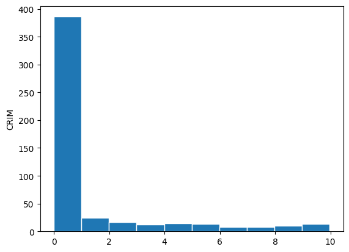

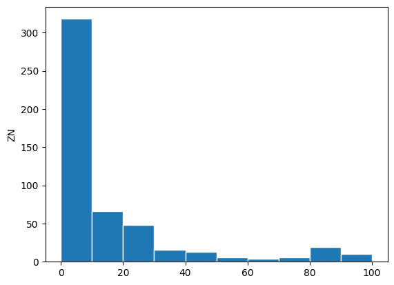

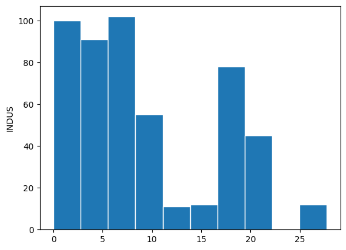

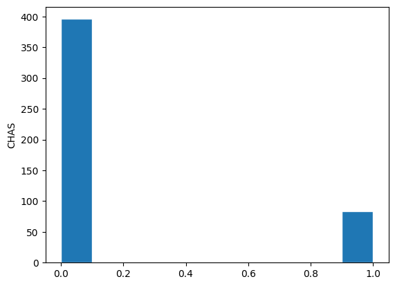

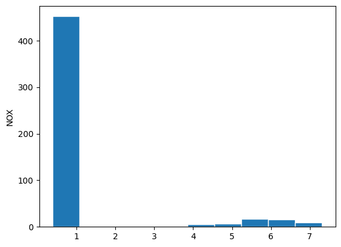

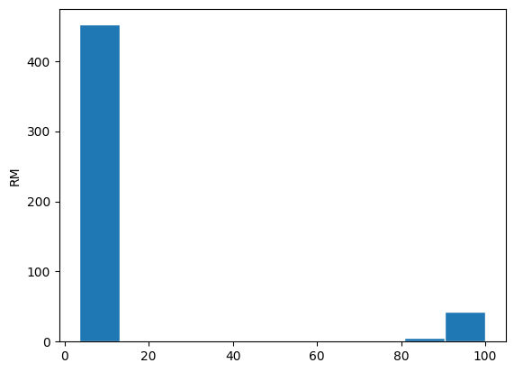

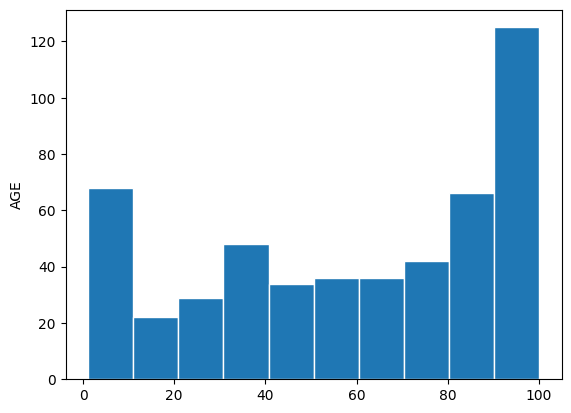

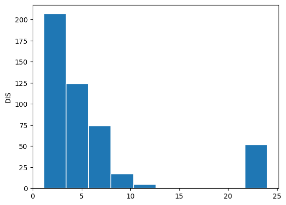

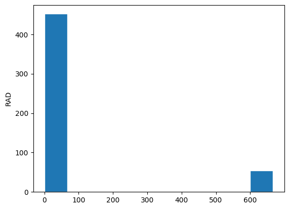

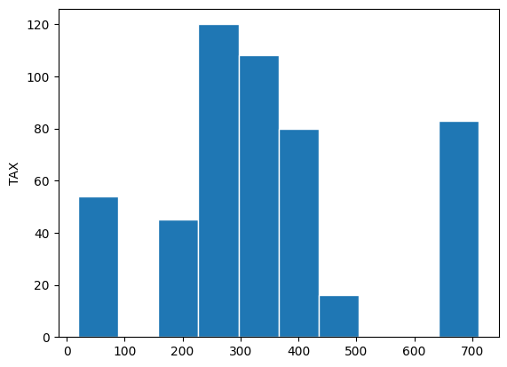

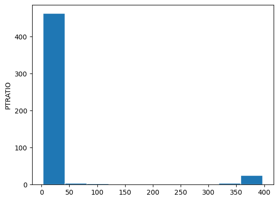

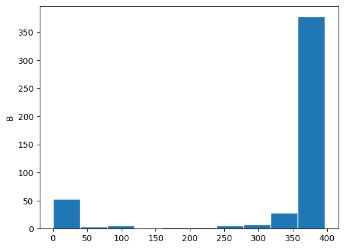

[2 more figures not shown]

```python
for feature in data:
    plt.hist(data[feature], edgecolor='white')
    plt.ylabel(feature)
    plt.show()
```

## Q4

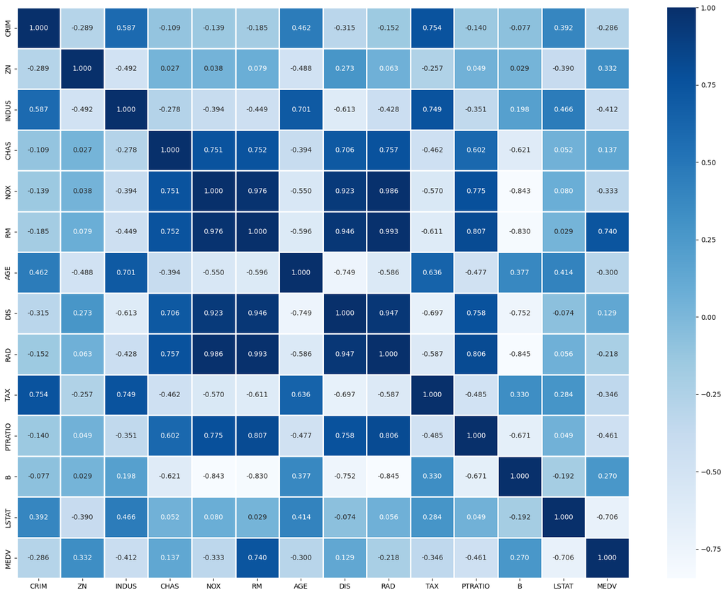

```python
corrResult = data.corr()
plt.figure(figsize=(20, 15))
seaborn.heatmap(corrResult, annot=True, fmt=".3f", linewidths=1, cmap="Blues")
```

```python
priceCorr = corrResult["MEDV"].drop("MEDV")
priceCorr
```

```
CRIM      -0.286245
ZN         0.331570
INDUS     -0.411915
CHAS       0.136668
NOX       -0.332778
RM         0.740181
AGE       -0.299893
DIS        0.129355
RAD       -0.217902
TAX       -0.345898
PTRATIO   -0.461214
B          0.269605
LSTAT     -0.706255
Name: MEDV, dtype: float64
```

```python
dependentToPrice = priceCorr[abs(priceCorr) > 0.35]
dependentToPrice
```

```
INDUS     -0.411915
RM         0.740181
PTRATIO   -0.461214
LSTAT     -0.706255
Name: MEDV, dtype: float64
```

## Q5

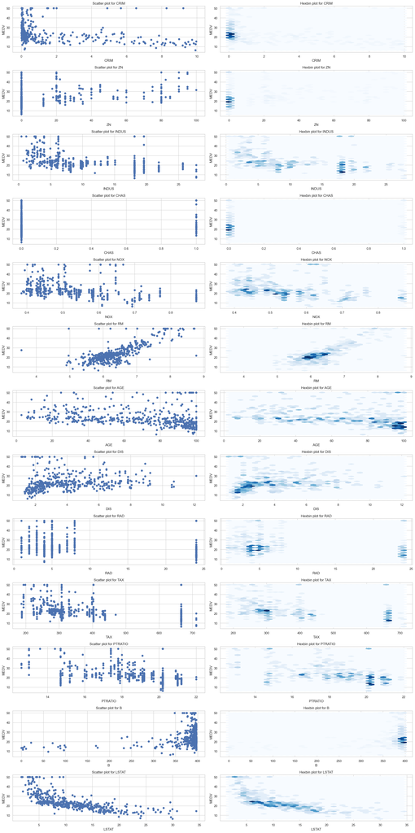

```python
fig, axs = plt.subplots(nrows=len(priceCorr.index), ncols=2, figsize=(20, 40))

for i, feature in enumerate(priceCorr.index):
    axs[i, 0].scatter(data[feature], data["MEDV"])
    axs[i, 0].set_title(f'Scatter plot for {feature}')
    axs[i, 0].set_xlabel(feature)
    axs[i, 0].set_ylabel("MEDV")

    axs[i, 1].hexbin(data[feature], data["MEDV"], gridsize=30, cmap='Blues')
    axs[i, 1].set_title(f'Hexbin plot for {feature}')
    axs[i, 1].set_xlabel(feature)
    axs[i, 1].set_ylabel("MEDV")

plt.tight_layout()
plt.show()
```

## Q6

It's also good to know what is the distribution of features visually

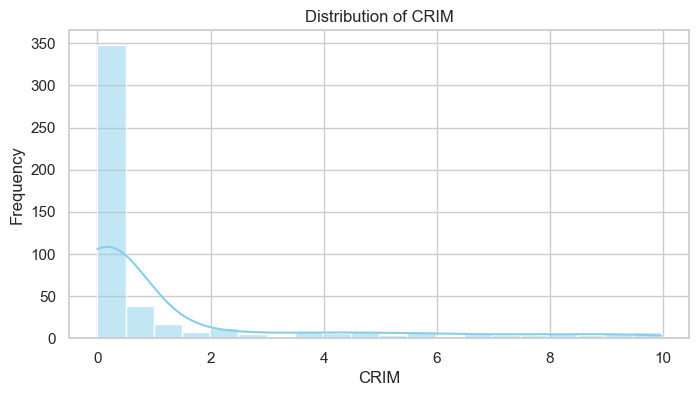

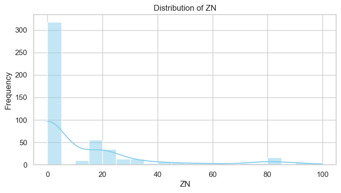

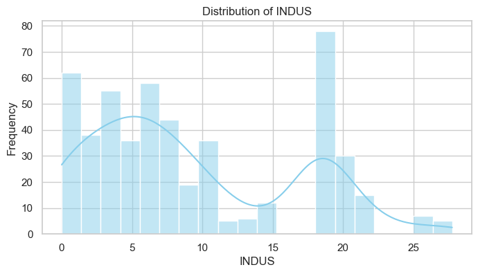

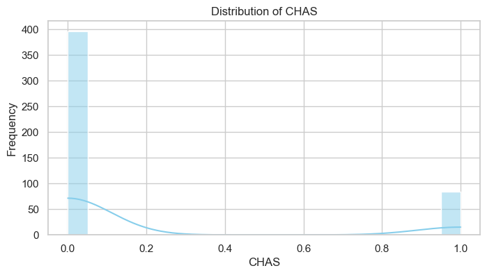

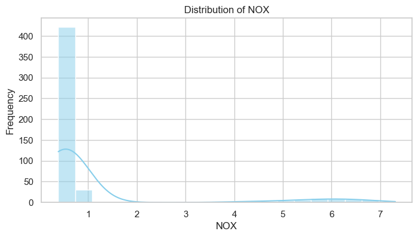

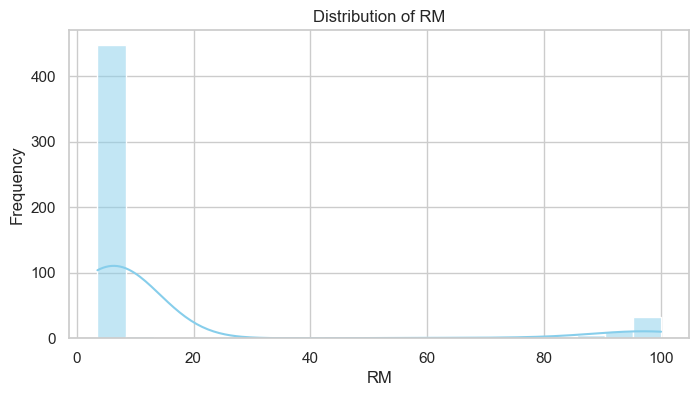

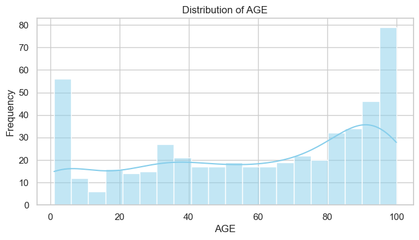

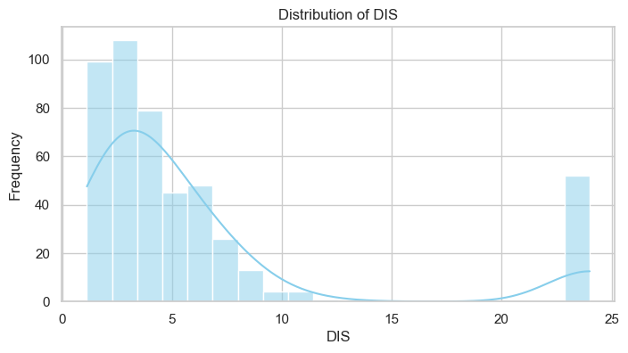

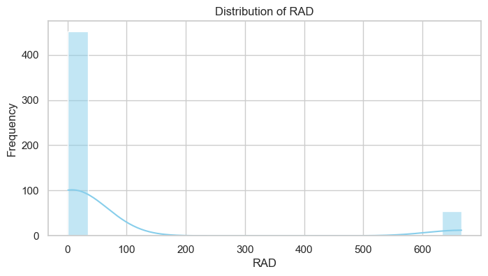

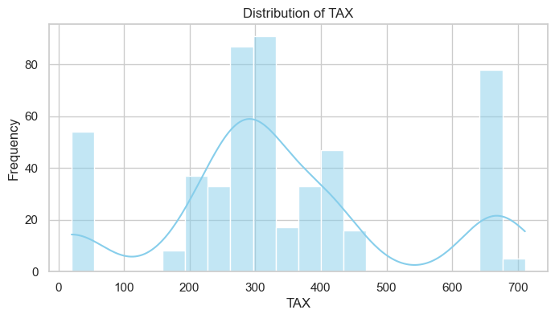

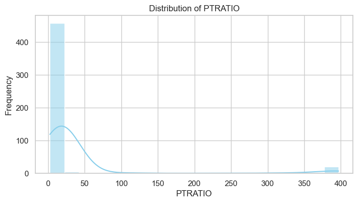

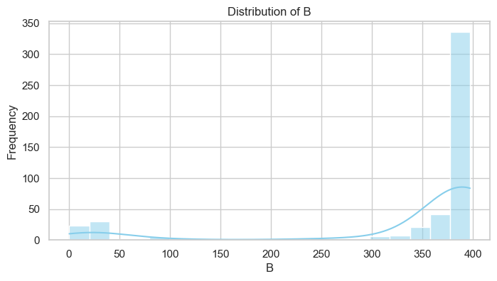

[2 more figures not shown]

```python
import seaborn as sns
sns.set(style="whitegrid")

for column in data.columns:
    plt.figure(figsize=(8, 4))
    sns.histplot(data[column], kde=True, color='skyblue', bins=20)
    plt.title(f"Distribution of {column}")
    plt.xlabel(column)
    plt.ylabel("Frequency")
    plt.show()
```

## Q7

```python
misseingsResult[misseingsResult["Missing"] != 0]
```

|  | Missing | Ratio |
| --- | --- | --- |
| CHAS | 26 | 0.051383 |
| DIS | 27 | 0.053360 |
| B | 20 | 0.039526 |
| MEDV | 54 | 0.106719 |

1. **Mean/Median Imputation**:
   - **Method**: Replace missing values with the **mean** (for continuous variables) or **median** (for skewed distributions) of the non-missing values in the same column.
   - **When to Use It**:
     - When the missing values are **completely at random (MCAR)** or **missing at random (MAR)**.
     - It's a simple approach that helps retain the sample size.
   - **Example**:
     - Suppose we have a dataset of house prices, and the square footage of some houses is missing. We can impute the missing square footage with the average square footage of the other houses in the dataset.

```python
missingCols = list(misseingsResult[misseingsResult["Missing"] != 0].index)
medianData = data.copy()
for col in missingCols:
    medianData.fillna(data[col].median(), inplace=True)
medianData.isna().sum()
```

```
CRIM       0
ZN         0
INDUS      0
CHAS       0
NOX        0
RM         0
AGE        0
DIS        0
RAD        0
TAX        0
PTRATIO    0
B          0
LSTAT      0
MEDV       0
dtype: int64
```

2. **Mode Imputation**:
   - **Method**: For **categorical variables**, replace missing values with the **mode** (most frequent value) of that variable.
   - **When to Use It**:
     - When dealing with categorical data (e.g., colors, car types, etc.).
     - Useful for maintaining the distribution of categories.
   - **Example**:
     - If we're analyzing customer preferences and the "favorite color" field is missing, we can impute it with the most common color (mode).

```python
import statistics

missingCols = list(misseingsResult[misseingsResult["Missing"] != 0].index)
modeData = data.copy()
for col in missingCols:
    modeData.fillna(statistics.mode(data[col]), inplace=True)
modeData.isna().sum()
```

```
CRIM       0
ZN         0
INDUS      0
CHAS       0
NOX        0
RM         0
AGE        0
DIS        0
RAD        0
TAX        0
PTRATIO    0
B          0
LSTAT      0
MEDV       0
dtype: int64
```

3. **Linear Interpolation**:
   - Linear interpolation estimates missing values based on the linear relationship between adjacent data points.
   - It assumes that the data follows a linear trend.
   - Here's how you can use linear interpolation in Python (using Pandas):

```python
linearData = data.copy()
linearData.interpolate(method ='linear', limit_direction ='both', inplace=True)
linearData.isna().sum()
```

```
CRIM       0
ZN         0
INDUS      0
CHAS       0
NOX        0
RM         0
AGE        0
DIS        0
RAD        0
TAX        0
PTRATIO    0
B          0
LSTAT      0
MEDV       0
dtype: int64
```

```python
data.columns
```

```
Index(['CRIM', 'ZN', 'INDUS', 'CHAS', 'NOX', 'RM', 'AGE', 'DIS', 'RAD', 'TAX',
       'PTRATIO', 'B', 'LSTAT', 'MEDV'],
      dtype='object')
```

## Q8

#### the possibility of deleting certain columns in a dataset and the reasons behind it:

1. **Irrelevant Information**:
   - Some columns may contain irrelevant information that is not useful for our specific analysis.
   - Example: In a customer database, the "mobile phone number" column might be irrelevant for financial analyses.
2. **Collinearity with Other Variables**:
   - Certain columns may be highly correlated with other variables, leading to multicollinearity.
   - Removing such columns simplifies the analysis and avoids redundancy.
   - Example: If two columns represent similar information (e.g., "price" and "cost"), we can remove one to avoid collinearity.
3. **Data Integrity and Fraud Prevention**:
   - Deleting columns can prevent data integrity issues or fraudulent data.
   - Example: If a financial dataset has a column with negative profits (which doesn't make sense), removing it ensures data accuracy.

```python
independentToPrice = priceCorr[abs(priceCorr) < 0.15]
independentToPrice
```

```
CHAS    0.136668
DIS     0.129355
Name: MEDV, dtype: float64
```

So CHAS and DIS are irrevelant information compare to the price and i drop them.

```python
linearData = linearData.drop(['CHAS', 'DIS'], axis = "columns")
```

## Q9

1. **Numerical Features**:
   - These features represent quantities or measurements and can take on numeric values.
   - In our project:
     - **CRIM**: Per capita crime rate by town.
     - **ZN**: Proportion of residential land zoned for lots over 25,000 sq.ft.
     - **INDUS**: Proportion of nonretail business acres per town.
     - **NOX**: Nitric oxides concentration (parts per 10 million).
     - **RM**: Average number of rooms per dwelling.
     - **AGE**: Proportion of owner-occupied units built prior to 1940.
     - **DIS**: Weighted distances to five Boston employment centers.
     - **RAD**: Index of accessibility to radial highways.
     - **TAX**: Full-value property-tax rate per $10,000.
     - **PTRATIO**: Pupil-teacher ratio by town.
     - **LSTAT**: Percentage of lower status of the population.
     - **MEDV**: Median value of owner-occupied homes in $1000s (target variable).
     - **B**: A function involving the proportion of blacks by town (specifically, (Bk - 0.63)^2)).
2. **Categorical Features**:
   - These features represent labels or categories and do not have inherent numeric values.
   - In our project:
     - **CHAS**: Charles River dummy variable (1 if tract bounds river, 0 otherwise). (Bk)).

## Q10

1. **Normalization**:
   - **Purpose**: Normalization is performed to scale numerical features to a common range. It ensures that all features have similar magnitudes, which can be helpful for certain machine learning algorithms.
   - **Method**: The most common normalization technique is **min-max scaling**. It transforms the feature values to a range between 0 and 1. The formula for min-max scaling is as follows: $$ X_{\text{normalized}} = \frac{X - X_{\text{min}}}{X_{\text{max}} - X_{\text{min}}} $$ where:
     - (X) is the original feature value.
     - (X_{\text{min}}) and (X_{\text{max}}) are the minimum and maximum values of the feature, respectively.
2. **Standardization**:
   - **Purpose**: Standardization (also known as z-score normalization) transforms features to have a mean of 0 and a standard deviation of 1. It is useful when features have different units or scales.
   - **Method**: The formula for standardization is as follows: $$ X_{\text{standardized}} = \frac{X - \mu}{\sigma} $$ where:
     - (X) is the original feature value.
     - (\mu) (mu) is the mean of the feature.
     - (\sigma) (sigma) is the standard deviation of the feature.
3. **Differences**:
   - Normalization scales features to a specific range (e.g., [0, 1]), while standardization centers features around 0 with a standard deviation of 1.
   - Normalization is sensitive to outliers, whereas standardization is more robust.
   - The choice between normalization and standardization depends on the specific problem and the behavior of the features.

We also need to normalize our data Because:

- It helps to improve the performance of some machine learning algorithms: Some machine learning algorithms, such as K-nearest neighbors (KNN), are sensitive to the scale of the input features. Normalizing the data can help to improve the performance of these algorithms by ensuring that all features are on a similar scale.
- it helps to avoid bias towards features with larger scales: When features have different scales, the machine learning algorithm may assign more importance to features with larger scales.
- it helps to reduce the influence of outliers: Outliers can have a significant impact on the mean and standard deviation of a feature, which can affect the performance of some machine learning algorithms.

```python
from sklearn.preprocessing import StandardScaler

std_scaler = StandardScaler()
numeric_cols = linearData.select_dtypes(include="number")
linearData[numeric_cols.columns] = std_scaler.fit_transform(numeric_cols)
linearData["MEDV"] = numeric_cols["MEDV"]
linearData
```

|  | CRIM | ZN | INDUS | NOX | RM | AGE | RAD | TAX | PTRATIO | B | LSTAT | MEDV |
| --- | --- | --- | --- | --- | --- | --- | --- | --- | --- | --- | --- | --- |
| 0 | -0.526893 | 0.204324 | -0.962669 | -0.342280 | -0.334818 | 0.195195 | -0.378985 | -0.239999 | -0.312176 | 0.506715 | -1.082336 | 24.0 |
| 1 | -0.518136 | -0.577404 | -0.298101 | -0.384216 | -0.340481 | 0.609451 | -0.374068 | -0.539182 | -0.283604 | 0.506715 | -0.395747 | 21.6 |
| 2 | -0.518144 | -0.577404 | -0.298101 | -0.384216 | -0.312386 | 0.071220 | -0.374068 | -0.539182 | -0.283604 | 0.473513 | -1.239130 | 34.7 |
| 3 | -0.516024 | -0.577404 | -0.980819 | -0.390902 | -0.319263 | -0.391416 | -0.369150 | -0.649991 | -0.273318 | 0.490114 | -1.419029 | 33.4 |
| 4 | -0.500721 | -0.577404 | -0.980819 | -0.390902 | -0.313783 | -0.137420 | -0.369150 | -0.649991 | -0.273318 | 0.506715 | -1.024570 | 36.2 |
| ... | ... | ... | ... | ... | ... | ... | ... | ... | ... | ... | ... | ... |
| 501 | -0.503399 | -0.577404 | 0.380429 | -0.321009 | -0.334156 | 0.313121 | -0.378985 | -0.367429 | -0.247032 | 0.466660 | -0.308273 | 22.4 |
| 502 | -0.510642 | -0.577404 | 0.380429 | -0.321009 | -0.351550 | 0.542928 | -0.378985 | -0.367429 | -0.247032 | 0.506715 | -0.405650 | 20.6 |
| 503 | -0.504180 | -0.577404 | 0.380429 | -0.321009 | -0.320072 | 0.975327 | -0.378985 | -0.367429 | -0.247032 | 0.506715 | -0.973406 | 23.9 |
| 504 | -0.483807 | -0.577404 | 0.380429 | -0.321009 | -0.326764 | 0.923923 | -0.378985 | -0.367429 | -0.247032 | 0.478570 | -0.834768 | 22.0 |
| 505 | -0.509750 | -0.577404 | 0.380429 | -0.321009 | -0.354860 | 0.666902 | -0.378985 | -0.367429 | -0.247032 | 0.506715 | -0.603704 | 11.9 |

506 rows × 12 columns

```python
from sklearn.model_selection import train_test_split

features = linearData.drop("MEDV", axis = "columns")
X_train, X_test, y_train, y_test = train_test_split(features, linearData["MEDV"], test_size=0.2, random_state=42)
```

```python
display(X_train)
display(y_train)
```

|  | CRIM | ZN | INDUS | NOX | RM | AGE | RAD | TAX | PTRATIO | B | LSTAT |
| --- | --- | --- | --- | --- | --- | --- | --- | --- | --- | --- | --- |
| 477 | -0.529530 | 0.208667 | -1.285180 | 2.554346 | 3.001482 | -1.712782 | 2.891384 | -1.768049 | 3.507083 | -2.527881 | 0.076283 |
| 15 | -0.267772 | -0.577404 | -0.148712 | -0.342280 | -0.362067 | -0.067873 | -0.364232 | -0.179054 | -0.247032 | 0.496273 | -0.506328 |
| 332 | -0.515069 | 0.942623 | -0.439112 | -0.403118 | -0.354823 | -1.071764 | -0.378985 | -0.195676 | -0.293890 | 0.224049 | -0.611957 |
| 423 | 2.412024 | -0.577404 | 1.241856 | -0.296090 | -0.352175 | 0.796924 | -0.265875 | 1.809959 | -0.256175 | -2.710533 | 1.939646 |
| 19 | -0.226714 | -0.577404 | -0.148712 | -0.342280 | -0.366002 | 0.325217 | -0.364232 | -0.179054 | -0.247032 | 0.458176 | -0.042550 |
| ... | ... | ... | ... | ... | ... | ... | ... | ... | ... | ... | ... |
| 106 | -0.458102 | -0.577404 | -0.090074 | -0.353220 | -0.361994 | 1.002541 | -0.359314 | 0.247559 | -0.248175 | 0.496681 | 1.175486 |
| 270 | -0.404715 | 0.291183 | -0.313458 | -0.387255 | -0.361258 | -0.503296 | -0.369150 | -0.644450 | -0.274461 | 0.439413 | 0.241328 |
| 348 | -0.523267 | 2.896943 | -1.004554 | -0.404881 | -0.332611 | -0.878243 | -0.364232 | -0.328646 | -0.292747 | 0.458095 | -0.915640 |
| 435 | -0.529530 | 0.208667 | -1.285180 | 3.359640 | 2.902193 | -1.712056 | 2.891384 | -1.768049 | 0.768412 | -2.541260 | 0.307347 |
| 102 | -0.434087 | -0.577404 | -0.090074 | -0.353220 | -0.341069 | 0.805996 | -0.359314 | 0.247559 | -0.248175 | -2.153522 | -0.149829 |

404 rows × 11 columns

```
477    18.275
15     19.900
332    19.400
423    13.400
19     18.200
        ...
106    19.500
270    21.100
348    24.500
435    13.800
102    18.600
Name: MEDV, Length: 404, dtype: float64
```

# Linear Regression

Main form of simple linear regression function: $$f(x) = \alpha x + \beta$$

- step 1: Compute RSS of the training data

$$ RSS = \Sigma (y_i - (\hat{\beta} + \hat{\alpha} * x_i) )^2 $$

- step 2: Compute the derivatives of the RSS function in terms of $\alpha$ and $\beta$, and set them equal to 0 to find the desired parameters

$$ \frac{\partial RSS}{\partial \beta} = \Sigma (-f(x_i) + \hat{\beta} + \hat{\alpha} * x_i) = 0$$ $$ \to \beta = \hat{y} - \hat{\alpha} \hat{x} \to (1)$$

$$ \frac{\partial RSS}{\partial \alpha} = \Sigma (-2 x_i y_i + 2 \hat{\beta} x_i + 2\hat{\alpha} x_i ^ 2) = 0 \to (2)$$

$$ (1) , (2) \to \hat{\alpha} = \frac{\Sigma{(x_i - \hat{x})(y_i - \hat{y})}}{\Sigma{(x_i - \hat{x})^2}} $$ $$ \hat{\beta} = y - \hat{a} x$$

## Q14

## Q15

## Q16

## Q17 & Q18 & Q19

Based on the corrolation i calculated, I expect LSTAT and RM get a better result compare to the other independent features but lets see the results for each...

Based on the above formula, implement the function below to compute the parameters of a simple linear regression

```python
import numpy as np
import math

def linearRegression(inputFeature, output):
    Sxy = (inputFeature * output).sum() - inputFeature.sum() * output.sum() / len(output)
    Sxx = (inputFeature ** 2).sum() - (inputFeature.sum())**2 / len(output)
    slope = Sxy / Sxx
    intercept = output.mean() - slope * inputFeature.mean()
    return (intercept, slope)
```

Now complete this `get_regression_predictions(...)` function to predict the value of given data based on the calculated intercept and slope

```python
def getRegressionPredictions(input, intercept, slope):
    return input * slope + intercept
```

Now that we have a model and can make predictions, let's evaluate our model using Root Mean Square Error (RMSE). RMSE is the square root of the mean of the squared differences between the residuals, and the residuals is just a fancy word for the difference between the predicted output and the true output.

Complete the following function to compute the RSME of a simple linear regression model given the input_feature, output, intercept and slope:

```python
def getRootMeanSquareError(predictedValues , output):
    residuals = predictedValues - output
    residualsSumSqr = (residuals ** 2).sum()
    meanResidualSqr = residualsSumSqr/len(predictedValues)
    return math.sqrt(meanResidualSqr)
```

The RMSE has no bound, thus it becomes challenging to determine whether a particular RMSE value is considered good or bad without any reference point. Instead, we use R2 score. The R2 score is calculated by comparing the sum of the squared differences between the actual and predicted values of the dependent variable to the total sum of squared differences between the actual and mean values of the dependent variable. The R2 score is formulated as below:

$$R^2 = 1 - \frac{SSres}{SStot} = 1 - \frac{\sum_{i=1}^{n} (y_{i,true} - y_{i,pred})^2}{\sum_{i=1}^{n} (y_{i,true} - \bar{y}_{true})^2} $$

```python
def getR2Score(predictedVals, actualVals):
    residuals = predictedVals - actualVals
    SSres = (residuals ** 2).sum()
    SStot = ((actualVals - actualVals.mean())**2).sum()
    return 1 - SSres / SStot
```

We have another famous metric too:

- `Mean Squared Error(MSE)`: The MSE measures the average of the squared differences between the predicted values and the actual values. The lower the MSE, the better the model fits the data. The formula for calculating MSE is: $$ MSE = \frac{1}{n}\sum{(y_{i,true} - y_{i,pred})^2} $$

For calculating the fitness of our model I wrote a new function(`testSimpleLinearRegression`) which gets a feature and make the model with that feature and the calculates R2 score and RMSE for it.

```python
def testSimpleLinearRegression(feature, ax):
    intercept, slope = linearRegression(X_train[feature], y_train)
    predictedValues = getRegressionPredictions(X_test[feature], intercept, slope)
    rmse = getRootMeanSquareError(predictedValues, y_test)
    r2_score = getR2Score(predictedValues, y_test)
    print(f"{feature}:\n RMSE: {rmse:0.3f}, R^2: {r2_score}")

    ax.scatter(y_test, predictedValues)
    ax.plot(y_test, y_test, color='red')

    ax.set_xlabel('Actual MEDVs')
    ax.set_ylabel("Predicted MEDVs")
    ax.set_title(feature)
    ax.legend()
```

Now calculate the fitness of the model. Remember to provide explanation for the outputs in your code!

[output not shown]

[output not shown]

```
INDUS:
 RMSE: 7.967, R^2: 0.05017954809396408
RM:
 RMSE: 7.974, R^2: 0.048514532291732526
PTRATIO:
 RMSE: 8.066, R^2: 0.026483506635118892
LSTAT:
 RMSE: 6.441, R^2: 0.3792119582840566
```

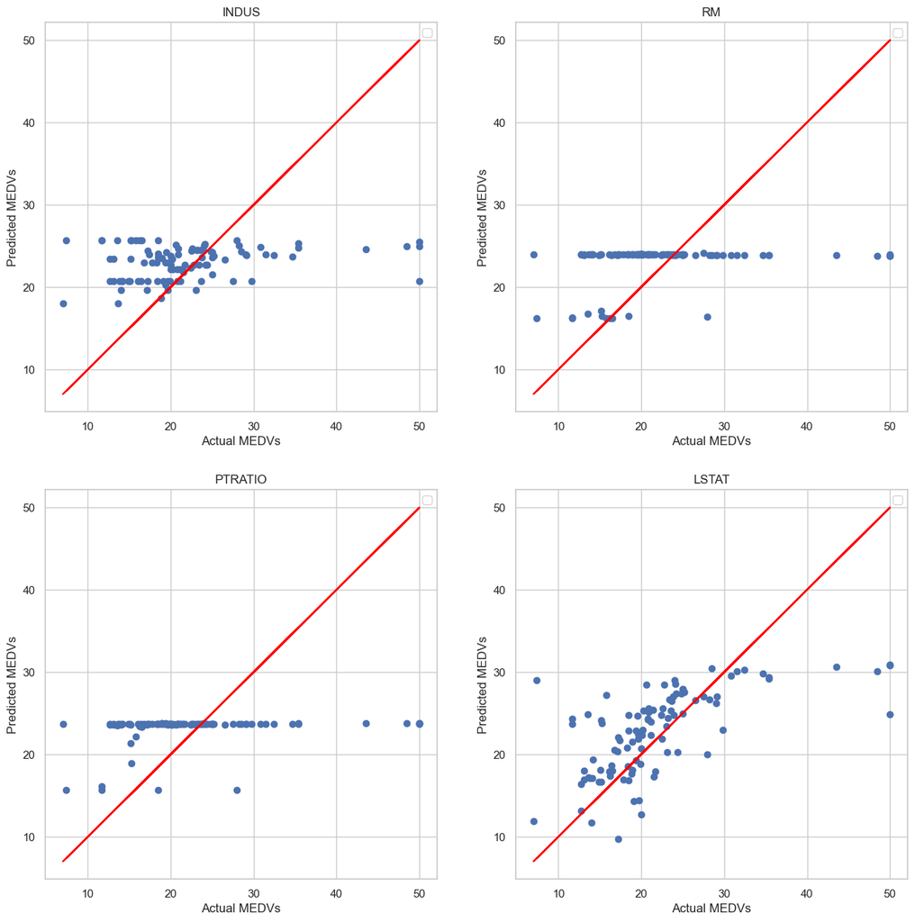

```python
designatedFeatureList = list(dependentToPrice.index)

figure, axs = plt.subplots(nrows=2, ncols=2, figsize=(15,15))
axs = axs.flatten()

for ax, feature in zip(axs, designatedFeatureList):
    testSimpleLinearRegression(feature, ax)
```

As you see, LSTAT has a way better R^2 Score and a better RMSE compare to others! So according to the corrolation value and the results i mentioned and the plot(the data points are closer to the line x=y compare to t\other features), I think LSTAT is the best feature to choose for predictions but R^2 is still less than 0.5 so we can just make our model base on a single feature and it's gonna be a very bad model!